# Assignment SQL

## Instructions

Complete the following exercises using the appropriate packages in R. Ensure that your solutions are optimized and use functional programming principles where applicable.

1. Load the necessary libraries.
2. Answer each question in separate R code chunks.
3. Provide detailed explanations for your approach.
4. **Instructions for Submitting the DBeaver Part of the Assignment**
- **Part I: Quarto / R Markdown Submission**
  1. For each section of Part I, **enter your answer in a separate code chunk**.
  2. Make sure your code runs correctly and produces the expected output.
- **Part II: DBeaver Screenshots**
  1. For each section of Part II, **take a screenshot of your query results in DBeaver** code and output must be visible.
  2. Insert the screenshots into the **appropriate sections of your Quarto/R Markdown document**.
> - Place each screenshot **directly after the corresponding answer section**.
3. After uploading all screenshots, **render the document** (HTML or PDF) **before submission**.
- **Important: Verification**
  - **Double-check that all images display correctly** in the rendered document **before and after submission**.
  - If any screenshot does not appear properly, you **must fix it and re-render** the document before the due date.
  - Only documents with all visible images will be graded for Part II. ## SQL
- Load Packages `DBI`, `duckdb`, `nycflights13` and anything else you need
- Download the duck database. https://data-science-master.github.io/lectures/data/flights.duckdb

```r
library(DBI)
library(duckdb)
library(dplyr)
library(dbplyr)
```

### Part I: Answer the following question by running SQL using **RStudio**.

#### a.

List the first **10 rows** of the `flights` table.

```r
conn <- dbConnect(duckdb(), "flights.duckdb", read_only = TRUE)
```

```
duckdb is storing downloaded extensions and secrets under ~/.duckdb:
ℹ /Users/nathankirner/.duckdb
This persists across sessions and is shared with the DuckDB CLI and other clients.
ℹ Run duckdb(shared_home = FALSE) to use a temporary directory instead.
ℹ See ?duckdb_storage for details and alternatives.
```

```r
dbIsValid(conn)
```

```
[1] TRUE
```

```r
flights <-"flights.duckdb"
tbl(conn, sql("SELECT * FROM 'flights'"))
```

```
# A query:  ?? x 19
# Database: DuckDB 1.5.6 [root@Darwin 25.6.0:R 4.6.1//Users/nathankirner/Documents/sql hw/flights.duckdb]
    year month   day dep_time sched_dep_time dep_delay arr_time sched_arr_time
   <int> <int> <int>    <int>          <int>     <dbl>    <int>          <int>
 1  2013     1     1      517            515         2      830            819
 2  2013     1     1      533            529         4      850            830
 3  2013     1     1      542            540         2      923            850
 4  2013     1     1      544            545        -1     1004           1022
 5  2013     1     1      554            600        -6      812            837
 6  2013     1     1      554            558        -4      740            728
 7  2013     1     1      555            600        -5      913            854
 8  2013     1     1      557            600        -3      709            723
 9  2013     1     1      557            600        -3      838            846
10  2013     1     1      558            600        -2      753            745
# ℹ more rows
# ℹ 11 more variables: arr_delay <dbl>, carrier <chr>, flight <int>,
#   tailnum <chr>, origin <chr>, dest <chr>, air_time <dbl>, distance <dbl>,
#   hour <dbl>, minute <dbl>, time_hour <dttm>
```

#### b.

Find the **number of flights**

1. in the dataset

```r
dbGetQuery(conn,"SELECT COUNT(*) FROM flights")
```

```
  count_star()
1       336776
```

2. for each carrier

```r
dbGetQuery(conn,"SELECT carrier, COUNT(*) FROM flights GROUP BY carrier")
```

```
   carrier count_star()
1       B6        54635
2       DL        48110
3       OO           32
4       AA        32729
5       EV        54173
6       US        20536
7       9E        18460
8       YV          601
9       UA        58665
10      MQ        26397
11      VX         5162
12      FL         3260
13      HA          342
14      WN        12275
15      AS          714
16      F9          685
```

#### c.

Find the **average departure delay** (`dep_delay`)

```r
dbGetQuery(conn, "SELECT AVG(dep_delay) FROM flights")
```

```
  avg(dep_delay)
1       12.63907
```

#### d.

Find the **top 5 destinations** (`dest`) With the most flights.

- Your output should include:
  - destination
  - number of flights Sort from the **largest to smallest**.

```r
dbGetQuery(conn, "SELECT dest,COUNT(*) AS 'flight_count' FROM flights GROUP BY dest ORDER BY flight_count DESC LIMIT 5") #create flight_count so you can group by them
```

```
  dest flight_count
1  ORD        17283
2  ATL        17215
3  LAX        16174
4  BOS        15508
5  MCO        14082
```

#### e.

Create a table showing:

- `carrier`
- average arrival delay (`arr_delay`)

Sort the results from **largest to smallest delay**

```r
dbGetQuery(conn, "SELECT carrier,AVG(arr_delay) AS delay_time,FROM flights GROUP BY carrier ORDER BY delay_time DESC  ")
```

```
   carrier delay_time
1       F9 21.9207048
2       FL 20.1159055
3       EV 15.7964311
4       YV 15.5569853
5       OO 11.9310345
6       MQ 10.7747334
7       WN  9.6491199
8       B6  9.4579733
9       9E  7.3796692
10      UA  3.5580111
11      US  2.1295951
12      VX  1.7644644
13      DL  1.6443409
14      AA  0.3642909
15      HA -6.9152047
16      AS -9.9308886
```

```r
dbDisconnect(conn,"flights.duckdb") #close connection
dbIsValid(conn) #check to make sure connection is closed
```

```
[1] FALSE
```

> You must close the connection when you are done. Use `dbDisconnect()`

### Part II: Answer the following question by running SQL using **DBeaver** with **DuckDB**.

> Please go over the note **dbeaver_sql.html** to learn

#### a.

List the first **10 rows** of the `flights` table.

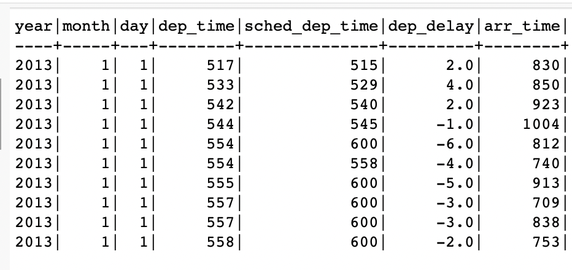

Question 1

#### b.

Count the Number of Flights for Each Carrier

Find the **number of flights** for each carrier.

- Your output should include:
  - carrier
  - number of flights Sort from the **largest to smallest**.

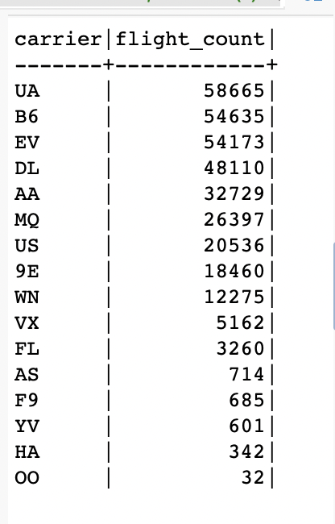

#### c.

Find the **average departure delayby month**

- Your output should include:
  - month
  - average departure delay

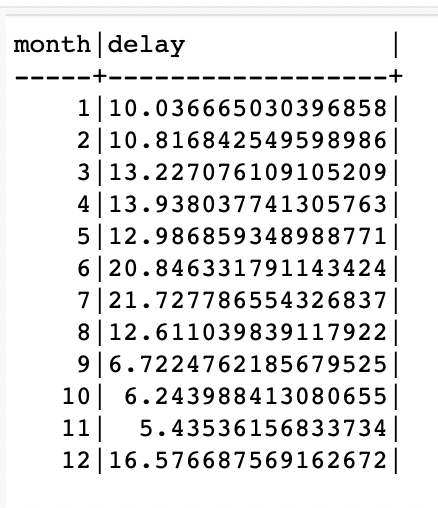

#### d.

Find the **top 10 routes** (`dest`) by:

- `origin`
- `dest`

ordered by **number of flights**.

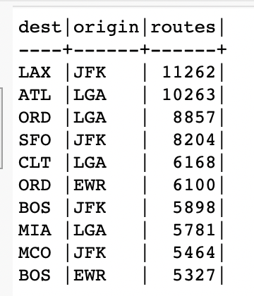

#### e.

Export the result of part b query to a **CSV file** using the **Export Data** feature in DBeaver.

Submit the exported CSV file along with your homework.

- **Exporting Data to CSV in DBeaver**

**NoteQuick Steps**

1. **Right-click** Table or Result Grid -> **Export Data**.
2. Select **CSV** -> Click **Next**.
3. Confirm **Settings** (Delimiters, Encoding) -> Click **Next**.
4. Choose **Output Directory** -> Click **Finish**.

## Remember to Close the connection When You Are Done

- **How to Disconnect and Reconnect a Database in DBeaver**
1. On the **top menu**, click **Database**.
2. From the drop-down menu, select **Disconnect**.
3. You should see a message on the **bottom right corner**:

   ```
   Not connected to database
   ```

4. To reconnect, go to **Database → Connect** and select your connection.

> This is the easiest way to manage connections without closing DBeaver or losing work.

## Submission

- Save your Quarto file after completing each problem, render it, then stage and commit the changes.
- Include well-commented code and clear explanations.
- Make appropriate **commits**.
- Submit the rendered file to **Canvas** and push it to your **GitHub repository**.

**Good luck!**